# Penalized Regression Splines

Roger Bukuru

2024-06-30

### Penalized Regression Splines

#### Definition

Penalized regression splines are an extension of regression splines that include a penalty term to control the smoothness of the fitted curve. This approach helps to prevent overfitting by penalizing the complexity of the spline, ensuring that the fitted curve is smooth and does not wiggle excessively to fit every data point.

#### Formulation

Penalized regression splines add a penalty term to the usual least squares objective function. The objective function for penalized regression splines can be written as:

$$\text{Objective Function} =
\sum_{i=1}^{n} (y_i - \hat{y}_i)^2 + \lambda \int [f''(x)]^2 \,
dx$$

where: - $y_i$ are the observed data points. - $\hat{y}_i$ are the predicted values from the spline. - $\lambda$ is a non-negative tuning parameter that controls the trade-off between fitting the data closely and ensuring smoothness. - $f''(x)$ is the second derivative of the spline function, representing the curvature of the spline.

#### Key Components

1. **Basis Functions**: Like standard splines, penalized regression splines use basis functions to construct the spline. Common choices include B-splines and truncated power basis functions.
2. **Penalty Term**: The penalty term $\lambda \int [f''(x)]^2 \, dx$ discourages large curvature, promoting smoothness. The parameter $\lambda$ controls the strength of the penalty:
   - $\lambda = 0$: No penalty, resulting in a spline that may overfit the data.
   - $\lambda \rightarrow \infty$: Strong penalty, resulting in a very smooth (possibly linear) spline.
3. **Smoothness Parameter ($\lambda$)**: This parameter is typically chosen using methods like cross-validation to balance the fit and smoothness of the spline.

#### Example in R

The `mgcv` package in R provides functionality for fitting penalized regression splines using the `gam` function (generalized additive models).

```r
# Load necessary library
library(mgcv)
```

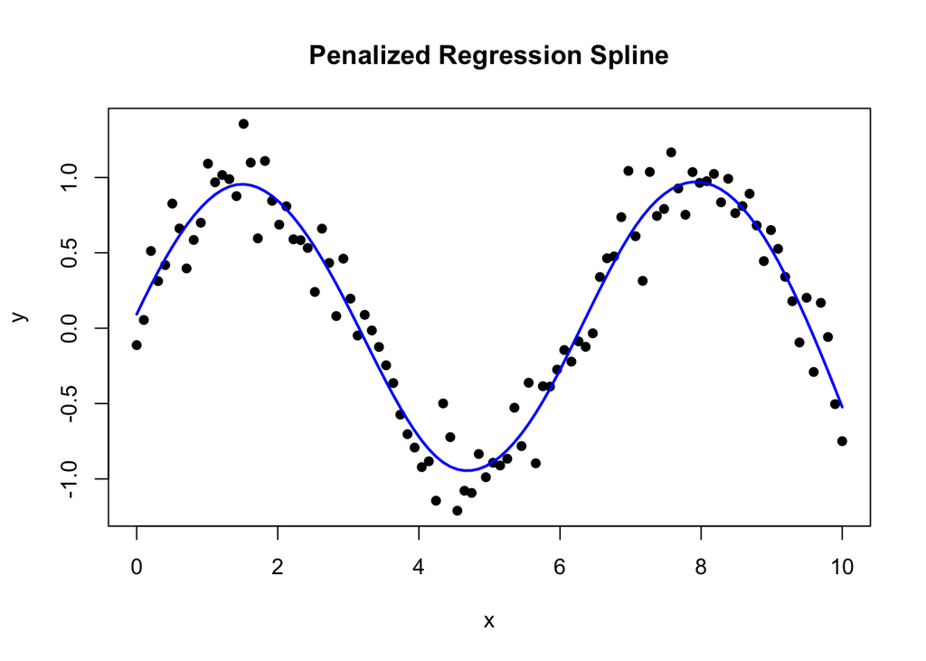

```r
# Generate example data
set.seed(123)
x <- seq(0, 10, length.out = 100)
y <- sin(x) + rnorm(100, sd = 0.2)

# Fit a penalized regression spline using the gam function
penalized_spline_fit <- gam(y ~ s(x, bs = "ps"))

# Plot the data and the fitted penalized regression spline
plot(x, y, main = "Penalized Regression Spline", pch = 16)
lines(x, predict(penalized_spline_fit, newdata = data.frame(x = x)), col = "blue", lwd = 2)
```

### Explanation of the Code

1. **Loading the Library**: `library(mgcv)` loads the `mgcv` package, which provides functions for fitting penalized regression splines.
2. **Generating Example Data**: `x` and `y` are generated to illustrate the fitting process.
3. **Fitting the Penalized Spline**: `penalized_spline_fit <- gam(y ~ s(x, bs = "ps"))` fits a penalized regression spline to the data. The `s(x, bs = "ps")` term specifies a penalized spline basis for the predictor `x`.
4. **Plotting**: The observed data and the fitted penalized regression spline are plotted to visualize the fit.

### Advantages of Penalized Regression Splines

1. **Automatic Smoothness Control**: The penalty term helps automatically control the smoothness of the fitted spline, reducing the risk of overfitting.
2. **Flexibility**: Penalized regression splines can handle a wide range of data patterns, including non-linear and complex relationships.
3. **Regularization**: The penalization acts as a regularization method, similar to ridge regression, improving the stability and generalizability of the model.

### Summary

Penalized regression splines extend standard regression splines by adding a penalty term that controls the smoothness of the fitted curve. This approach balances the trade-off between fitting the data closely and ensuring the spline is smooth, preventing overfitting. The smoothness parameter $\lambda$ is crucial in this process, typically chosen through cross-validation.